# What are some questions that I can answer with this dataset?

## Statistic resume

### Numeric variables

```python
df.iloc[:, :20].describe().transpose()
```

|  | count | mean | std | min | 25% | 50% | 75% | max |
| --- | --- | --- | --- | --- | --- | --- | --- | --- |
| acepta_permuta | 913.00 | 1.00 | 0.00 | 1.00 | 1.00 | 1.00 | 1.00 | 1.00 |
| altura_permitida | 310.00 | 21.76 | 93.38 | 5.00 | 9.00 | 13.00 | 23.50 | 1650.00 |
| ambientes | 2880.00 | 2.28 | 1.67 | 1.00 | 1.00 | 2.00 | 3.00 | 7.00 |
| ambientes_extra | 2880.00 | 0.10 | 0.31 | 0.00 | 0.00 | 0.00 | 0.00 | 1.00 |
| ano_de_construccion | 16116.00 | 1988.39 | 58.75 | 1060.00 | 1963.00 | 1998.00 | 2017.00 | 7880.00 |
| aptos_por_piso | 6362.00 | 5.46 | 100.38 | 1.00 | 2.00 | 3.00 | 5.00 | 8000.00 |
| banos | 25044.00 | 1.65 | 0.78 | 1.00 | 1.00 | 1.00 | 2.00 | 3.00 |
| banos_extra | 25044.00 | 0.19 | 0.39 | 0.00 | 0.00 | 0.00 | 0.00 | 1.00 |
| cantidad_de_pisos | 6512.00 | 8.50 | 26.65 | 1.00 | 4.00 | 10.00 | 10.00 | 2101.00 |
| casco | 21.00 | 1.00 | 0.00 | 1.00 | 1.00 | 1.00 | 1.00 | 1.00 |
| distancia_al_mar | 5164.00 | 421.48 | 352.69 | 0.00 | 100.00 | 300.00 | 500.00 | 1000.00 |
| dormitorios | 23034.00 | 2.29 | 1.22 | 0.00 | 2.00 | 2.00 | 3.00 | 5.00 |
| dormitorios_extra | 23034.00 | 0.05 | 0.21 | 0.00 | 0.00 | 0.00 | 0.00 | 1.00 |
| financia | 4276.00 | 1.00 | 0.00 | 1.00 | 1.00 | 1.00 | 1.00 | 1.00 |

```python
# df.hvplot.hist(y='precio', bins=range(0, 4000000, 20000), xlim=(0, 4000000), groupby='barrio')
```

### Categeries resume

```python
df.describe(include='O').transpose()
```

|  | count | unique | top | freq |
| --- | --- | --- | --- | --- |
| barrio | 26229 | 89 | pocitos | 4126 |
| descripcion | 28388 | 27127 | la zona: 01 del centro esta ubicado en el limi... | 19 |
| direccion | 9195 | 6592 | 26 de marzo | 55 |
| disposicion | 18954 | 4 | al frente | 15804 |
| estado | 25504 | 7 | buen estado | 10527 |
| extra | 23097 | 14664 | garaje | 1000 |
| inmobiliaria | 28476 | 1025 | las torres | 1102 |
| referencia | 26317 | 26312 | 4E979 | 2 |
| sobre | 8199 | 3 | otros | 4444 |
| tipo_de_publicacion | 26322 | 1 | venta | 26322 |
| tipo_propiedad | 26223 | 12 | apartamentos | 17127 |
| titulo_publicacion | 28542 | 22607 | apartamento en venta 2 dormitorios | 242 |
| url | 28620 | 28588 | https://www.infocasas.com.uy/proyectos/tempo-g... | 2 |

```python
report = pandas_profiling.ProfileReport(df)
report.to_file('../report/dataset/report.html')
```

# Data prepratation

**The quality and quantity of data that you gather will directly determine how good your predictive model can be.**

- Exploratory data analysis (visualization)
- Select relevant features
- Clean and Missing values imputetion

## Select feature for analysis

Check dataset [documentation](https://github.com/creyesp/houses-project/blob/add-binder-configs/data/dataset_description.md) to choice the most interesting feature to answer our questions.

```python
columns_to_analyze = [
#     'ano_de_construccion',
    'banos',
    'banos_extra',
    'descripcion',
    'disposicion',
    'distancia_al_mar',
    'dormitorios',
    'dormitorios_extra',
    'estado',
    'extra',
    'garajes',
    'garajes_extra',
    'gastos_comunes',
    'tipo_de_publicacion',
    'm2_de_la_terraza',
    'm2_del_terreno',
    'm2_edificados',
    'oficina',
    'penthouse',
    'plantas',
    'plantas_extra',
    'precio',
    'sobre',
    'tipo_propiedad',
    'vista_al_mar',
    'vivienda_social',
    'barrio',
]
```

## Split dataset in numerical and string variables

```python
df_num = df[columns_to_analyze].select_dtypes(exclude='O')
df_obj = df[columns_to_analyze].select_dtypes(include='O')

print('Numerical columns: {}\n'.format(df_num.columns.tolist()))
print('Caterorial columns: {}'.format(df_obj.columns.tolist()))
```

```
Numerical columns: ['banos', 'banos_extra', 'distancia_al_mar', 'dormitorios', 'dormitorios_extra', 'garajes', 'garajes_extra', 'gastos_comunes', 'm2_de_la_terraza', 'm2_del_terreno', 'm2_edificados', 'oficina', 'penthouse', 'plantas', 'plantas_extra', 'precio', 'vista_al_mar', 'vivienda_social']

Caterorial columns: ['descripcion', 'disposicion', 'estado', 'extra', 'tipo_de_publicacion', 'sobre', 'tipo_propiedad', 'barrio']
```

## Missing values imputation

```python
# Fill missing values with zero
fill_zero_col = [
    'm2_de_la_terraza',
    'vivienda_social',
    'gastos_comunes',
    'garajes',
    'garajes_extra',
    'plantas_extra',
    'penthouse',
    'oficina',
]
df_num.loc[:, fill_zero_col] = df_num[fill_zero_col].fillna(0)

# Fill missing values with 1
df_num['plantas'].fillna(1, inplace=True)

# Fill missing value usings other columns
mask_m2_terreno = df_num['m2_del_terreno'].isna()
df_num.loc[mask_m2_terreno, 'm2_del_terreno'] = df_num.loc[mask_m2_terreno, 'm2_edificados']

# Fill missing categories
df_obj['barrio'].fillna('desconocido', inplace=True)
df_obj['disposicion'].fillna('otro', inplace=True)
```

## Feature transformation

Categorical:

- Nominal: apply ONEHOT encoding to transform to numerical variables (use pd.get_dummies(train, columns = dummy_cols))

```python
df_num['cerca_rambla'] = (df_num['distancia_al_mar'] <= 1000) | (df_num['vista_al_mar'] ).astype(float)
# df_num.drop(columns=['distancia_al_mar', 'vista_al_mar'], inplace=True)

df_num['m2_index'] = df_num['m2_edificados']/df_num['m2_del_terreno']
# df_num.drop(columns=['m2_del_terreno'], inplace=True)

# Categorical transformation
map_status = {
    'en construccion': 3,
    'a estrenar': 3,
    'excelente estado': 3,
    'buen estado': 2,
    'reciclada': 2,
    'requiere mantenimiento': 1,
    'a reciclar': 0,
#     '': np.nan,
}
df_num['estado'] = df_obj['estado'].map(map_status)
df_num['parrilero'] = df_obj['extra'].str.contains('parrillero').fillna(False)
zona = pd.get_dummies(utils.pareto_rule(df_obj['barrio']), prefix='ZN_',)
disp = pd.get_dummies(df_obj['disposicion'], prefix='DISP_')

df_num_final = pd.concat([df_num, zona, disp], axis=1)
df_num_final.drop(columns=['distancia_al_mar', 'vista_al_mar', 'm2_del_terreno'], inplace=True)
```

## Apply customs filters

```python
df_num_final.quantile([0.01, 0.95]).transpose()
```

|  | 0.01 | 0.95 |
| --- | --- | --- |
| banos | 1.00 | 3.00 |
| banos_extra | 0.00 | 1.00 |
| dormitorios | 0.00 | 4.00 |
| dormitorios_extra | 0.00 | 0.00 |
| garajes | 0.00 | 2.00 |
| garajes_extra | 0.00 | 0.00 |
| gastos_comunes | 0.00 | 16000.00 |
| m2_de_la_terraza | 0.00 | 35.00 |
| m2_edificados | 2.62 | 357.00 |
| oficina | 0.00 | 1.00 |
| penthouse | 0.00 | 0.00 |
| plantas | 1.00 | 3.00 |
| plantas_extra | 0.00 | 1.00 |
| precio | 43545.00 | 881145.00 |
| vivienda_social | 0.00 | 1.00 |
| cerca_rambla | 0.00 | 1.00 |
| m2_index | 0.20 | 1.35 |
| estado | 0.00 | 3.00 |
| parrilero | 0.00 | 1.00 |
| ZN__aguada | 0.00 | 0.00 |
| ZN__buceo | 0.00 | 0.00 |
| ZN__carrasco | 0.00 | 1.00 |
| ZN__centro | 0.00 | 1.00 |
| ZN__ciudad vieja | 0.00 | 0.00 |
| ZN__cordon | 0.00 | 1.00 |
| ZN__desconocido | 0.00 | 1.00 |
| ZN__la blanqueada | 0.00 | 0.00 |
| ZN__malvin | 0.00 | 1.00 |
| ZN__otros | 0.00 | 1.00 |
| ZN__parque batlle | 0.00 | 0.00 |
| ZN__parque rodo | 0.00 | 0.00 |
| ZN__pocitos | 0.00 | 1.00 |
| ZN__pocitos nuevo | 0.00 | 0.00 |
| ZN__prado | 0.00 | 0.00 |
| ZN__punta carretas | 0.00 | 1.00 |
| ZN__tres cruces | 0.00 | 0.00 |
| DISP__al frente | 0.00 | 1.00 |
| DISP__contrafrente | 0.00 | 1.00 |
| DISP__interior | 0.00 | 0.00 |
| DISP__lateral | 0.00 | 0.00 |
| DISP__otro | 0.00 | 1.00 |

```python
mask = (
    df_obj['tipo_propiedad'].isin(['apartamentos', 'casas'])
    & (df_num_final['oficina'] != 1)
#     & (df_num_final['penthouse'] != 1)
    & (df_num_final['banos'].between(1, 3))
    & (df_num_final['dormitorios'].between(0, 5))
    & (df_num_final['garajes'].between(0, 5))
    & (df_num_final['m2_de_la_terraza'] >= 0)
#     & (df_num_final['m2_del_terreno'] >= 10)
    & (df_num_final['m2_edificados'] >= 10)
    & (df_num_final['gastos_comunes'].between(0, 50000))
    & (df_num_final['precio'].between(0, 2e6))
#     & (df_num_final['cantidad_de_pisos'].between(1, 30))
#     & (df_num_final['ano_de_construccion'].between(1880, 2019))
#     & (df_num_final['aptos_por_piso'].between(1, 20))

)
mask.sum()
```

```
18914
```

## Drop no informative columns and drop missing row

```python
zero_std_col = df_num_final.columns[df_num_final[mask].std() == 0]
df_final = df_num_final[mask].drop(columns=zero_std_col).astype(float).dropna()
```

```python
df
```

[output not shown]

28620 rows × 46 columns

```python
utils.info(df_final)
```

|  | dtypes | isnull | %null | nunique |
| --- | --- | --- | --- | --- |
| banos | float64 | False | 0.00 | 3 |
| banos_extra | float64 | False | 0.00 | 2 |
| dormitorios | float64 | False | 0.00 | 6 |
| dormitorios_extra | float64 | False | 0.00 | 2 |
| garajes | float64 | False | 0.00 | 6 |
| garajes_extra | float64 | False | 0.00 | 2 |
| gastos_comunes | float64 | False | 0.00 | 741 |
| m2_de_la_terraza | float64 | False | 0.00 | 209 |
| m2_edificados | float64 | False | 0.00 | 538 |
| penthouse | float64 | False | 0.00 | 2 |
| plantas | float64 | False | 0.00 | 3 |
| plantas_extra | float64 | False | 0.00 | 2 |
| precio | float64 | False | 0.00 | 1775 |
| vivienda_social | float64 | False | 0.00 | 2 |
| cerca_rambla | float64 | False | 0.00 | 2 |
| m2_index | float64 | False | 0.00 | 2734 |
| estado | float64 | False | 0.00 | 4 |
| parrilero | float64 | False | 0.00 | 2 |
| ZN__aguada | float64 | False | 0.00 | 2 |
| ZN__buceo | float64 | False | 0.00 | 2 |
| ZN__carrasco | float64 | False | 0.00 | 2 |
| ZN__centro | float64 | False | 0.00 | 2 |
| ZN__ciudad vieja | float64 | False | 0.00 | 2 |
| ZN__cordon | float64 | False | 0.00 | 2 |
| ZN__desconocido | float64 | False | 0.00 | 2 |
| ZN__la blanqueada | float64 | False | 0.00 | 2 |
| ZN__malvin | float64 | False | 0.00 | 2 |
| ZN__otros | float64 | False | 0.00 | 2 |
| ZN__parque batlle | float64 | False | 0.00 | 2 |
| ZN__parque rodo | float64 | False | 0.00 | 2 |
| ZN__pocitos | float64 | False | 0.00 | 2 |
| ZN__pocitos nuevo | float64 | False | 0.00 | 2 |
| ZN__prado | float64 | False | 0.00 | 2 |
| ZN__punta carretas | float64 | False | 0.00 | 2 |
| ZN__tres cruces | float64 | False | 0.00 | 2 |
| DISP__al frente | float64 | False | 0.00 | 2 |
| DISP__contrafrente | float64 | False | 0.00 | 2 |
| DISP__interior | float64 | False | 0.00 | 2 |
| DISP__lateral | float64 | False | 0.00 | 2 |
| DISP__otro | float64 | False | 0.00 | 2 |

## Binning

Some variable like years or ages is an example of a feature type that might benefit from transformation into a discrete variable.

```python
# pd.cut(df.ano_de_construccion, bins=np.arange(1880, 2020, 10))
```

## Save ready dataset

```python
df_final.to_csv('../data/ready/dataset_houses.csv', index=False)
```

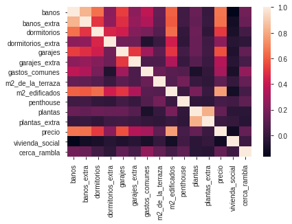

```python
sns.heatmap(df_final.corr().iloc[:15, :15])
```

## Feature Scaling

The continuous variables in our dataset are at varying scales. This poses a problem for many popular machine learning algorithms which often use Euclidian distance between data points to make the final predictions. Standardising the scale for all continuous variables can often result in an increase in performance of machine learning models.

```python
from sklearn.preprocessing import MinMaxScaler
from sklearn.preprocessing import MaxAbsScaler
from sklearn.preprocessing import StandardScaler
from sklearn.preprocessing import RobustScaler
from sklearn.preprocessing import QuantileTransformer
from sklearn.preprocessing import PowerTransformer
from sklearn.preprocessing import Normalizer
```

```python
# scaler = QuantileTransformer(output_distribution='normal')
# scaler = PowerTransformer(method='yeo-johnson')
scaler = StandardScaler()
# scaler = MinMaxScaler()
```

```python
data_set = df_final.drop(columns=['precio'])
target = df_final['precio']

norm = pd.DataFrame(scaler.fit_transform(data_set), columns=data_set.columns)
```

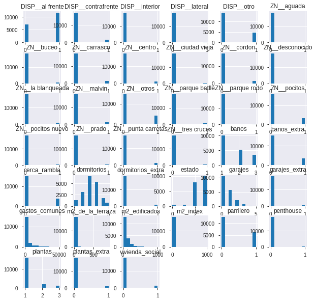

```python
data_set.hist(figsize=(10, 10));
```

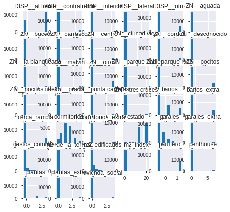

```python
norm.hist(figsize=(7,7));
```

```python
norm.describe().transpose()
```

|  | count | mean | std | min | 25% | 50% | 75% | max |
| --- | --- | --- | --- | --- | --- | --- | --- | --- |
| banos | 18835.00 | 0.00 | 1.00 | -0.84 | -0.84 | -0.84 | 0.46 | 1.75 |
| banos_extra | 18835.00 | 0.00 | 1.00 | -0.48 | -0.48 | -0.48 | -0.48 | 2.10 |
| dormitorios | 18835.00 | -0.00 | 1.00 | -1.95 | -0.24 | -0.24 | 0.62 | 2.34 |
| dormitorios_extra | 18835.00 | -0.00 | 1.00 | -0.20 | -0.20 | -0.20 | -0.20 | 5.06 |
| garajes | 18835.00 | 0.00 | 1.00 | -0.75 | -0.75 | -0.75 | 0.44 | 5.21 |
| garajes_extra | 18835.00 | -0.00 | 1.00 | -0.18 | -0.18 | -0.18 | -0.18 | 5.48 |
| gastos_comunes | 18835.00 | 0.00 | 1.00 | -0.55 | -0.55 | -0.55 | 0.11 | 7.11 |
| m2_de_la_terraza | 18835.00 | 0.00 | 1.00 | -0.27 | -0.27 | -0.27 | -0.16 | 33.36 |
| m2_edificados | 18835.00 | -0.00 | 1.00 | -1.01 | -0.57 | -0.36 | 0.19 | 9.01 |
| penthouse | 18835.00 | 0.00 | 1.00 | -0.14 | -0.14 | -0.14 | -0.14 | 7.26 |
| plantas | 18835.00 | -0.00 | 1.00 | -0.40 | -0.40 | -0.40 | -0.40 | 3.39 |
| plantas_extra | 18835.00 | -0.00 | 1.00 | -0.24 | -0.24 | -0.24 | -0.24 | 4.13 |
| vivienda_social | 18835.00 | -0.00 | 1.00 | -0.27 | -0.27 | -0.27 | -0.27 | 3.75 |
| cerca_rambla | 18835.00 | -0.00 | 1.00 | -0.50 | -0.50 | -0.50 | -0.50 | 1.98 |
| m2_index | 18835.00 | -0.00 | 1.00 | -0.21 | -0.14 | -0.14 | -0.14 | 21.02 |
| estado | 18835.00 | 0.00 | 1.00 | -3.70 | -0.69 | 0.81 | 0.81 | 0.81 |
| parrilero | 18835.00 | 0.00 | 1.00 | -0.70 | -0.70 | -0.70 | 1.43 | 1.43 |
| ZN__aguada | 18835.00 | 0.00 | 1.00 | -0.14 | -0.14 | -0.14 | -0.14 | 7.00 |
| ZN__buceo | 18835.00 | 0.00 | 1.00 | -0.18 | -0.18 | -0.18 | -0.18 | 5.49 |
| ZN__carrasco | 18835.00 | -0.00 | 1.00 | -0.29 | -0.29 | -0.29 | -0.29 | 3.45 |
| ZN__centro | 18835.00 | 0.00 | 1.00 | -0.27 | -0.27 | -0.27 | -0.27 | 3.76 |
| ZN__ciudad vieja | 18835.00 | 0.00 | 1.00 | -0.11 | -0.11 | -0.11 | -0.11 | 9.31 |
| ZN__cordon | 18835.00 | 0.00 | 1.00 | -0.30 | -0.30 | -0.30 | -0.30 | 3.34 |
| ZN__desconocido | 18835.00 | -0.00 | 1.00 | -0.05 | -0.05 | -0.05 | -0.05 | 18.48 |
| ZN__la blanqueada | 18835.00 | 0.00 | 1.00 | -0.23 | -0.23 | -0.23 | -0.23 | 4.33 |
| ZN__malvin | 18835.00 | 0.00 | 1.00 | -0.26 | -0.26 | -0.26 | -0.26 | 3.85 |
| ZN__otros | 18835.00 | 0.00 | 1.00 | -0.54 | -0.54 | -0.54 | -0.54 | 1.84 |
| ZN__parque batlle | 18835.00 | 0.00 | 1.00 | -0.19 | -0.19 | -0.19 | -0.19 | 5.31 |
| ZN__parque rodo | 18835.00 | 0.00 | 1.00 | -0.14 | -0.14 | -0.14 | -0.14 | 6.95 |
| ZN__pocitos | 18835.00 | 0.00 | 1.00 | -0.45 | -0.45 | -0.45 | -0.45 | 2.23 |
| ZN__pocitos nuevo | 18835.00 | -0.00 | 1.00 | -0.16 | -0.16 | -0.16 | -0.16 | 6.29 |
| ZN__prado | 18835.00 | -0.00 | 1.00 | -0.17 | -0.17 | -0.17 | -0.17 | 5.84 |
| ZN__punta carretas | 18835.00 | 0.00 | 1.00 | -0.26 | -0.26 | -0.26 | -0.26 | 3.88 |
| ZN__tres cruces | 18835.00 | 0.00 | 1.00 | -0.17 | -0.17 | -0.17 | -0.17 | 5.93 |
| DISP__al frente | 18835.00 | -0.00 | 1.00 | -1.29 | -1.29 | 0.78 | 0.78 | 0.78 |
| DISP__contrafrente | 18835.00 | 0.00 | 1.00 | -0.30 | -0.30 | -0.30 | -0.30 | 3.36 |
| DISP__interior | 18835.00 | 0.00 | 1.00 | -0.17 | -0.17 | -0.17 | -0.17 | 5.73 |
| DISP__lateral | 18835.00 | -0.00 | 1.00 | -0.14 | -0.14 | -0.14 | -0.14 | 6.90 |
| DISP__otro | 18835.00 | -0.00 | 1.00 | -0.57 | -0.57 | -0.57 | -0.57 | 1.76 |

# Why Feature Selection?

- Overfitting
- Occam’s Razor: "Entities should not be multiplied without necessity." William of Ockham
- Garbage In Garbage out: Most of the times, we will have many non-informative features.

Type of Feature Selection:

- Filter based: We specify some metric and based on that filter features. An example of such a metric could be correlation/chi-square.
- Wrapper-based: Wrapper methods consider the selection of a set of features as a search problem. Example: Recursive Feature Elimination
- Embedded: Embedded methods use algorithms that have built-in feature selection methods. For instance, Lasso and RF have their own feature selection methods.

```python
num_feats = 20
feature_name = data_set.columns.to_list()
```

## Filter based

```python
corr = df_final.corr()['precio'].drop('precio')
high_corr = np.abs(corr) > 0.5
corr_feature = high_corr.index.tolist()
corr_support = high_corr.to_numpy()
```

## Recursive Feature Elimination

```python
from sklearn.feature_selection import RFE
from sklearn.linear_model import LinearRegression


rfe_selector = RFE(estimator=LinearRegression(), n_features_to_select=num_feats, step=1, verbose=5, )
rfe_selector.fit(data_set, target)
rfe_support = rfe_selector.get_support()
rfe_feature = data_set.loc[:,rfe_support].columns.tolist()
print(str(len(rfe_feature)), 'selected features')
```

```
Fitting estimator with 39 features.
Fitting estimator with 38 features.
Fitting estimator with 37 features.
Fitting estimator with 36 features.
Fitting estimator with 35 features.
Fitting estimator with 34 features.
Fitting estimator with 33 features.
Fitting estimator with 32 features.
Fitting estimator with 31 features.
Fitting estimator with 30 features.
Fitting estimator with 29 features.
Fitting estimator with 28 features.
Fitting estimator with 27 features.
Fitting estimator with 26 features.
Fitting estimator with 25 features.
Fitting estimator with 24 features.
Fitting estimator with 23 features.
Fitting estimator with 22 features.
Fitting estimator with 21 features.
20 selected features
```

## Embebed

Embedded methods use algorithms that have built-in feature selection methods.

### Lasso

For example, Lasso and RF have their own feature selection methods. Lasso Regularizer forces a lot of feature weights to be zero.

```python
from sklearn.feature_selection import SelectFromModel
from sklearn.linear_model import Lasso

embeded_lr_selector = SelectFromModel(Lasso(), max_features=num_feats)
embeded_lr_selector.fit(data_set, target)

embeded_lr_support = embeded_lr_selector.get_support()
embeded_lr_feature = data_set.loc[:,embeded_lr_support].columns.tolist()
print(str(len(embeded_lr_feature)), 'selected features')
```

```
20 selected features
```

```python
embeded_lr_feature
```

```
['banos',
 'banos_extra',
 'dormitorios_extra',
 'garajes',
 'garajes_extra',
 'penthouse',
 'plantas_extra',
 'estado',
 'ZN__aguada',
 'ZN__buceo',
 'ZN__carrasco',
 'ZN__centro',
 'ZN__ciudad vieja',
 'ZN__cordon',
 'ZN__la blanqueada',
 'ZN__pocitos nuevo',
 'ZN__prado',
 'ZN__punta carretas',
 'ZN__tres cruces',
 'DISP__otro']
```

### RandomForest

We can also use RandomForest to select features based on feature importance.

```python
from sklearn.feature_selection import SelectFromModel
from sklearn.ensemble import RandomForestRegressor

embeded_rf_selector = SelectFromModel(RandomForestRegressor(n_estimators=100, max_depth=10, min_samples_leaf=10), max_features=num_feats)
embeded_rf_selector.fit(data_set, target)

embeded_rf_support = embeded_rf_selector.get_support()
embeded_rf_feature = data_set.loc[:,embeded_rf_support].columns.tolist()
print(str(len(embeded_rf_feature)), 'selected features')
```

```
6 selected features
```

```python
from sklearn.tree import DecisionTreeRegressor

embeded_rf_selector = SelectFromModel(DecisionTreeRegressor(), max_features=num_feats)
embeded_rf_selector.fit(data_set, target)

embeded_rf_support = embeded_rf_selector.get_support()
embeded_rf_feature = data_set.loc[:,embeded_rf_support].columns.tolist()
print(str(len(embeded_rf_feature)), 'selected features')
```

```
6 selected features
```

```python
# from sklearn.feature_selection import SelectFromModel
from lightgbm import LGBMRegressor

lgbr=LGBMRegressor(n_estimators=500, learning_rate=0.05, num_leaves=32, colsample_bytree=0.2,
            reg_alpha=3, reg_lambda=1, min_split_gain=0.01, min_child_weight=40)

embeded_lgb_selector = SelectFromModel(lgbr, max_features=num_feats)
embeded_lgb_selector.fit(data_set, target)

embeded_lgb_support = embeded_lgb_selector.get_support()
embeded_lgb_feature = data_set.loc[:,embeded_lgb_support].columns.tolist()
print(str(len(embeded_lgb_feature)), 'selected features')
```

```
11 selected features
```

```python
# put all selection together
feature_selection_df = pd.DataFrame(
    {
        'Feature':feature_name,
        'Pearson':corr_support,
        'RFE':rfe_support,
        'Logistics':embeded_lr_support,
        'Random Forest':embeded_rf_support,
        'LightGBM':embeded_lgb_support
    })
# count the selected times for each feature
feature_selection_df['Total'] = np.sum(feature_selection_df, axis=1)
# display the top 100
feature_selection_df = feature_selection_df.sort_values(['Total','Feature'] , ascending=False)
feature_selection_df.index = range(1, len(feature_selection_df)+1)
feature_selection_df.head(num_feats)
```

|  | Feature | Pearson | RFE | Logistics | Random Forest | LightGBM | Total |
| --- | --- | --- | --- | --- | --- | --- | --- |
| 1 | garajes | True | False | True | True | True | 4 |
| 2 | banos | True | False | True | True | True | 4 |
| 3 | m2_edificados | True | False | False | True | True | 3 |
| 4 | banos_extra | True | False | True | True | False | 3 |
| 5 | m2_index | False | False | False | True | True | 2 |
| 6 | gastos_comunes | False | False | False | True | True | 2 |
| 7 | estado | False | False | True | False | True | 2 |
| 8 | dormitorios | True | False | False | False | True | 2 |
| 9 | ZN__tres cruces | False | True | True | False | False | 2 |
| 10 | ZN__prado | False | True | True | False | False | 2 |
| 11 | ZN__pocitos nuevo | False | True | True | False | False | 2 |
| 12 | ZN__la blanqueada | False | True | True | False | False | 2 |
| 13 | ZN__cordon | False | True | True | False | False | 2 |
| 14 | ZN__ciudad vieja | False | True | True | False | False | 2 |
| 15 | ZN__centro | False | True | True | False | False | 2 |
| 16 | ZN__buceo | False | True | True | False | False | 2 |
| 17 | ZN__aguada | False | True | True | False | False | 2 |
| 18 | DISP__otro | False | True | True | False | False | 2 |
| 19 | DISP__al frente | False | True | False | False | True | 2 |
| 20 | plantas_extra | False | False | True | False | False | 1 |

```python
from scipy import stats
```

```python
stats.pointbiserialr(df_final['precio'], df_final['banos_extra'])
```

```
PointbiserialrResult(correlation=0.651255588561545, pvalue=0.0)
```

```python
stats.pointbiserialr(df_final['precio'], df_final['banos_extra'])
```

```
PointbiserialrResult(correlation=0.651255588561545, pvalue=0.0)
```

```python
def cramers_v(x, y):
    """ calculate Cramers V statistic for categorial-categorial association.
        uses correction from Bergsma and Wicher,
        Journal of the Korean Statistical Society 42 (2013): 323-328
    """
    confusion_matrix = pd.crosstab(x,y)
    chi2 = ss.chi2_contingency(confusion_matrix)[0]
    n = confusion_matrix.sum().sum()
    phi2 = chi2/n
    r,k = confusion_matrix.shape
    phi2corr = max(0, phi2-((k-1)*(r-1))/(n-1))
    rcorr = r-((r-1)**2)/(n-1)
    kcorr = k-((k-1)**2)/(n-1)
    return np.sqrt(phi2corr/min((kcorr-1),(rcorr-1)))
```

```python
confusion_matrix = pd.crosstab(df_final['dormitorios'], df_final['banos'])
confusion_matrix
```

| banos dormitorios | 1.0 | 2.0 | 3.0 |
| --- | --- | --- | --- |
| 0.00 | 1301 | 7 | 3 |
| 1.00 | 3036 | 71 | 2 |
| 2.00 | 4302 | 2094 | 197 |
| 3.00 | 1257 | 2386 | 1739 |
| 4.00 | 155 | 528 | 1049 |
| 5.00 | 56 | 168 | 484 |

```python
cramer = cramers_corrected_stat(confusion_matrix)
cramer
```

[output not shown]